# Module13 Notes

# Model Checking

Another important thing we need to do is check that the assumptions of linear modeling are met: (1) the residuals are normally distributed, (2) there is a constant variance in Y values across the range of X values

## Challenge

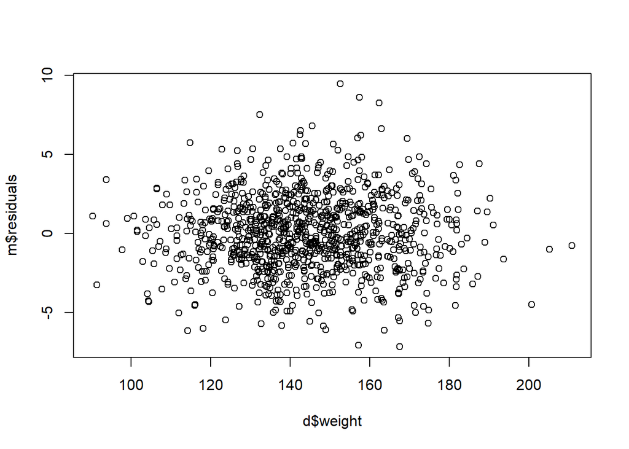

```r
m <- lm(data=d, height ~ weight)
plot(x = d$weight, y = m$residuals)
```

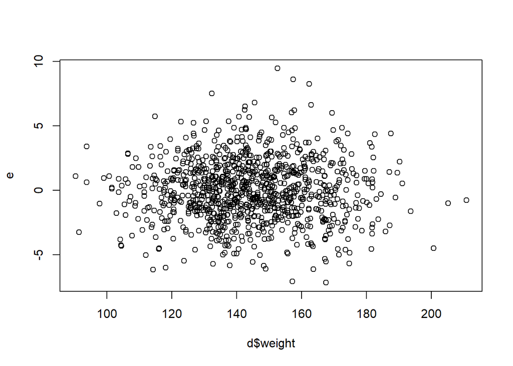

```r
#alternative
e <- resid(m)
plot(x = d$weight, y = e)
```

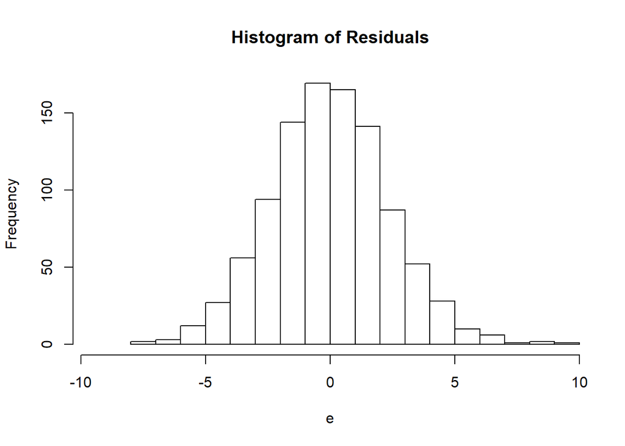

```r
hist(e, xlim = c(-4 * sd(e), 4 * sd(e)), breaks = 20, main = "Histogram of Residuals")
```

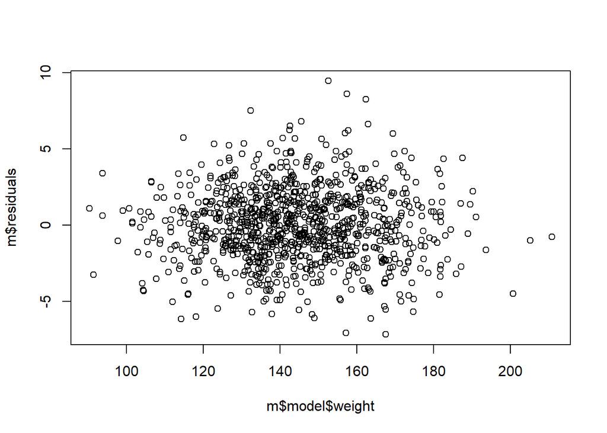

```r
#alternative
plot(m$model$weight, m$residuals)
```

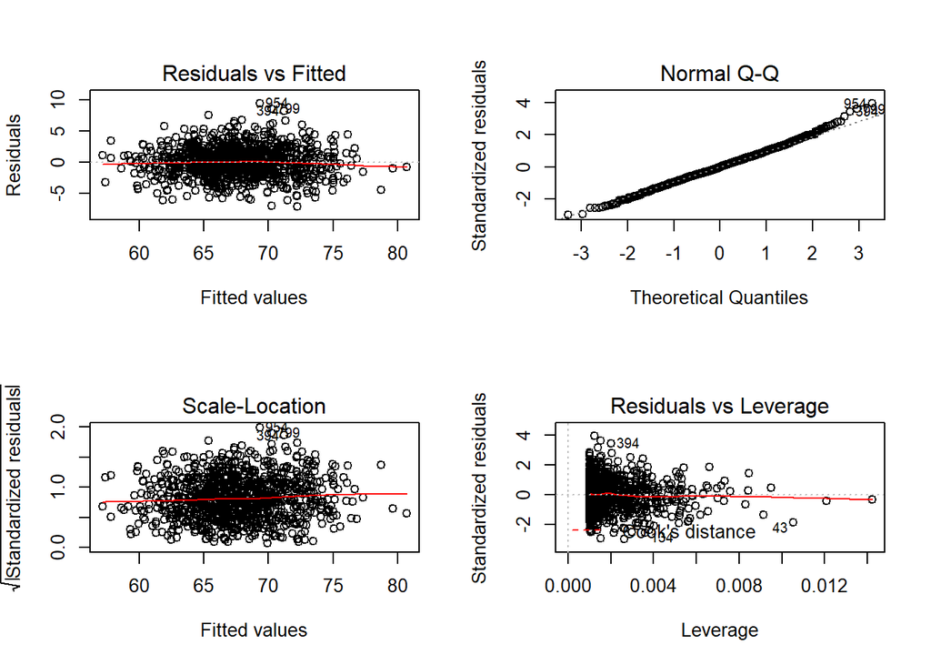

```r
par(mfrow = c(2, 2))
plot(m)
```

Using the last couple lines of code:

- the QQ plot should show a relatively straight line if the residuals are normally distributed
- the third plot graphs the square roots of the standardized residuals versus x–shows whether the residuals are equally disributed along the range of x; you want to see a horizontal line with equally spread points
- the fourth plot shows whether there are particular observations that influence the results

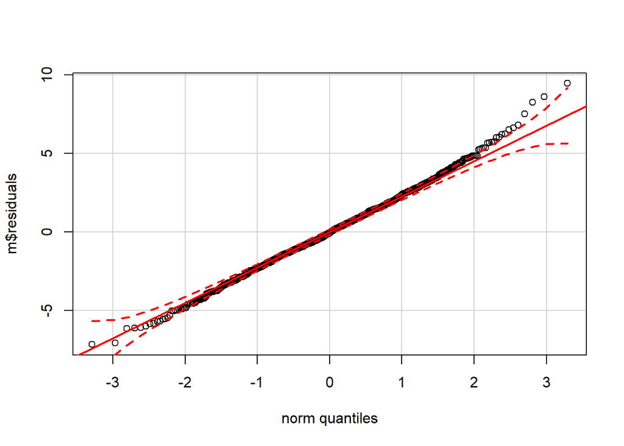

```r
library(car)
qqPlot(m$residuals) #shows trendline and CI
```

```r
s <- shapiro.test(m$residuals)
```

Shapiro-Wilk normality test: a low p value means deviation from normality

**other tests for normality are on Module 13**

# Challenge

```r
f <- curl("https://raw.githubusercontent.com/fuzzyatelin/fuzzyatelin.github.io/master/AN597_Fall17/KamilarAndCooperData.csv")
d <- read.csv(f, header = TRUE, sep = ",", stringsAsFactors = FALSE)
head(d)
```

```
##               Scientific_Name          Family          Genus      Species
## 1 Allenopithecus_nigroviridis Cercopithecidae Allenopithecus nigroviridis
## 2         Allocebus_trichotis Cercopithecidae      Allocebus    trichotis
## 3           Alouatta_belzebul        Atelidae       Alouatta     belzebul
## 4             Alouatta_caraya        Atelidae       Alouatta       caraya
## 5            Alouatta_guariba        Atelidae       Alouatta      guariba
## 6           Alouatta_palliata        Atelidae       Alouatta     palliata
##   Brain_Size_Species_Mean Brain_Size_Female_Mean   Brain_size_Ref
## 1                   58.02                  53.70 Isler et al 2008
## 2                      NA                     NA
## 3                   52.84                  51.19 Isler et al 2008
## 4                   52.63                  47.80 Isler et al 2008
## 5                   51.70                  49.08 Isler et al 2008
## 6                   49.88                  48.04 Isler et al 2008
##   Body_mass_male_mean Body_mass_female_mean Mass_Dimorphism
```

[output cut: 69 more lines]

```r
w <- d$WeaningAge_d
b <- d$Body_mass_female_mean
beta1 <- cor(w, b) * sd(w)/sd(b)
beta1 #still getting an NA value
```

```
## [1] NA
```

```r
beta1 <- cor(d$WeaningAge_d, d$Body_mass_female_mean) * sd(d$WeaningAge_d)/sd(d$Body_mass_female_mean)
beta1 #this didn't work
```

```
## [1] NA
```

```r
beta0 <- mean(d$WeaningAge_d) - beta1 * mean(d$Body_mass_female_mean)
beta0
```

```
## [1] NA
```

```r
m <- lm(WeaningAge_d ~ Body_mass_female_mean, data = d)
summary(m)
```

```
##
## Call:
## lm(formula = WeaningAge_d ~ Body_mass_female_mean, data = d)
##
## Residuals:
##     Min      1Q  Median      3Q     Max
## -720.39 -115.48  -54.05   58.11  471.22
##
## Coefficients:
##                        Estimate Std. Error t value Pr(>|t|)
## (Intercept)           2.016e+02  2.012e+01   10.02   <2e-16 ***
## Body_mass_female_mean 2.013e-02  1.927e-03   10.44   <2e-16 ***
## ---
## Signif. codes:  0 '***' 0.001 '**' 0.01 '*' 0.05 '.' 0.1 ' ' 1
##
## Residual standard error: 183.4 on 114 degrees of freedom
##   (97 observations deleted due to missingness)
## Multiple R-squared:  0.489,  Adjusted R-squared:  0.4845
## F-statistic: 109.1 on 1 and 114 DF,  p-value: < 2.2e-16
```

```r
summary.aov(m)
```

```
##                        Df  Sum Sq Mean Sq F value Pr(>F)
## Body_mass_female_mean   1 3668116 3668116   109.1 <2e-16 ***
## Residuals             114 3833822   33630
## ---
## Signif. codes:  0 '***' 0.001 '**' 0.01 '*' 0.05 '.' 0.1 ' ' 1
## 97 observations deleted due to missingness
```

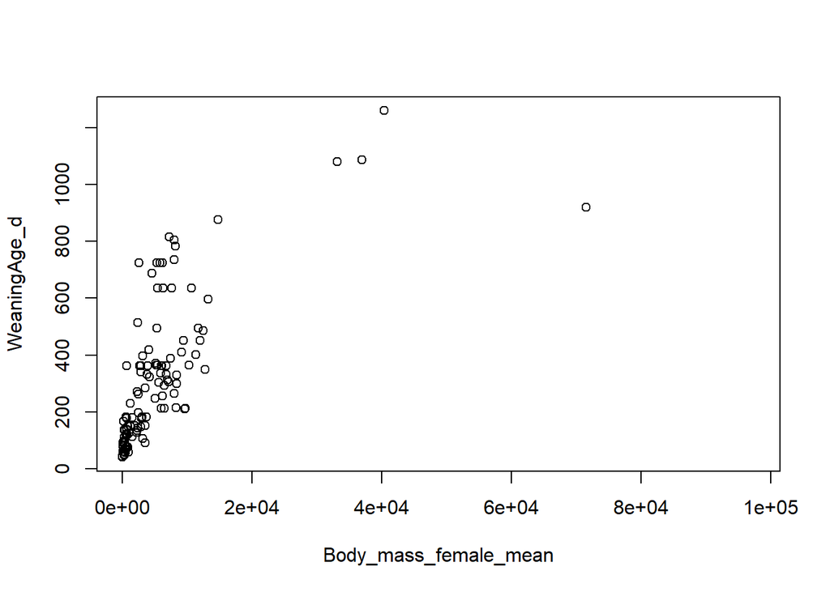

```r
plot(data = d, WeaningAge_d ~ Body_mass_female_mean)
```

```r
model <- lm(data = d, WeaningAge_d ~ Body_mass_female_mean)
summary(model)
```

```
##
## Call:
## lm(formula = WeaningAge_d ~ Body_mass_female_mean, data = d)
##
## Residuals:
##     Min      1Q  Median      3Q     Max
## -720.39 -115.48  -54.05   58.11  471.22
##
## Coefficients:
##                        Estimate Std. Error t value Pr(>|t|)
## (Intercept)           2.016e+02  2.012e+01   10.02   <2e-16 ***
## Body_mass_female_mean 2.013e-02  1.927e-03   10.44   <2e-16 ***
## ---
## Signif. codes:  0 '***' 0.001 '**' 0.01 '*' 0.05 '.' 0.1 ' ' 1
##
## Residual standard error: 183.4 on 114 degrees of freedom
##   (97 observations deleted due to missingness)
## Multiple R-squared:  0.489,  Adjusted R-squared:  0.4845
## F-statistic: 109.1 on 1 and 114 DF,  p-value: < 2.2e-16
```

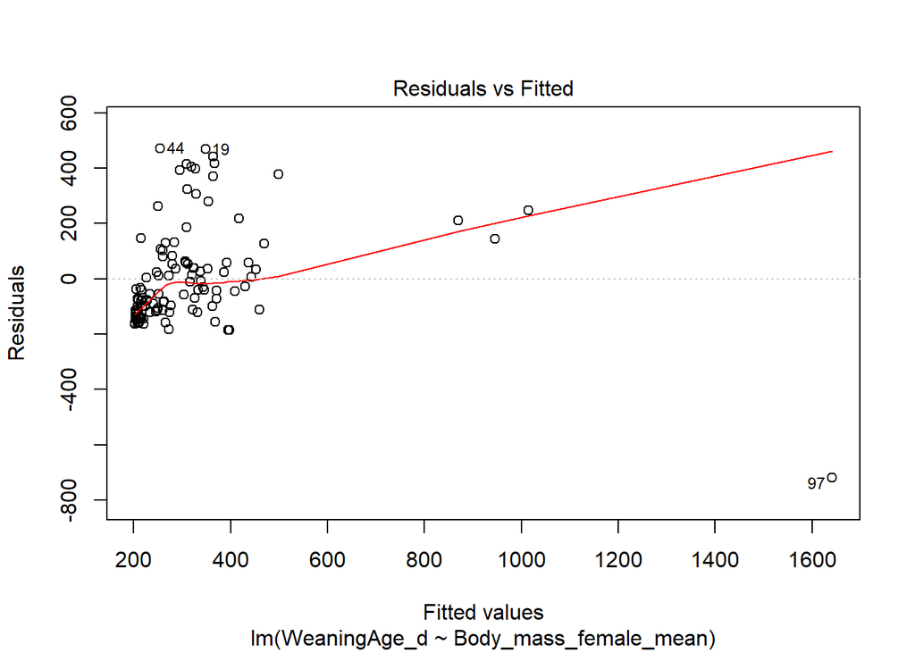

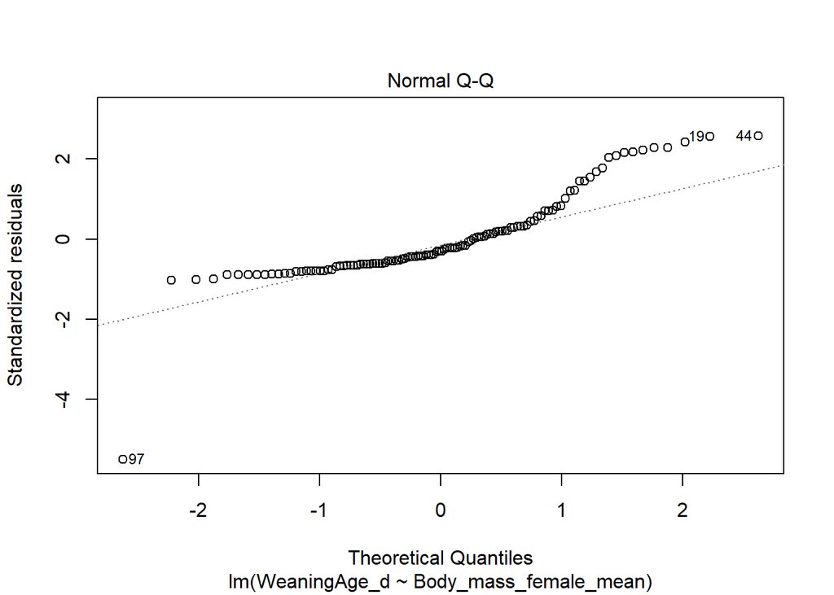

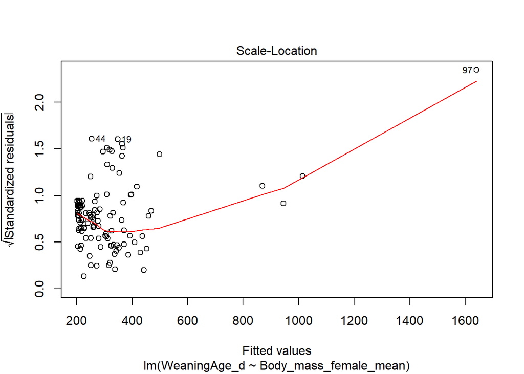

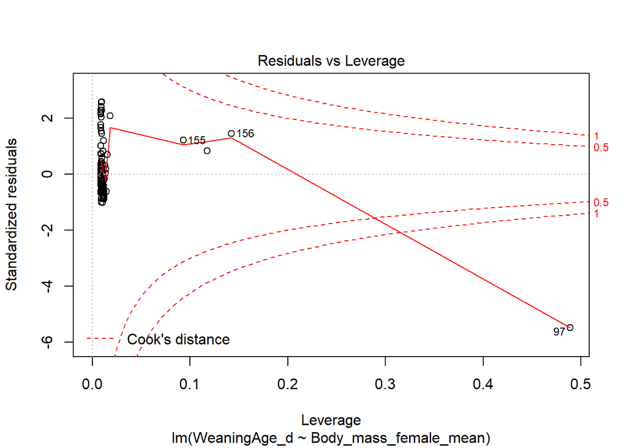

```r
plot(model)
```

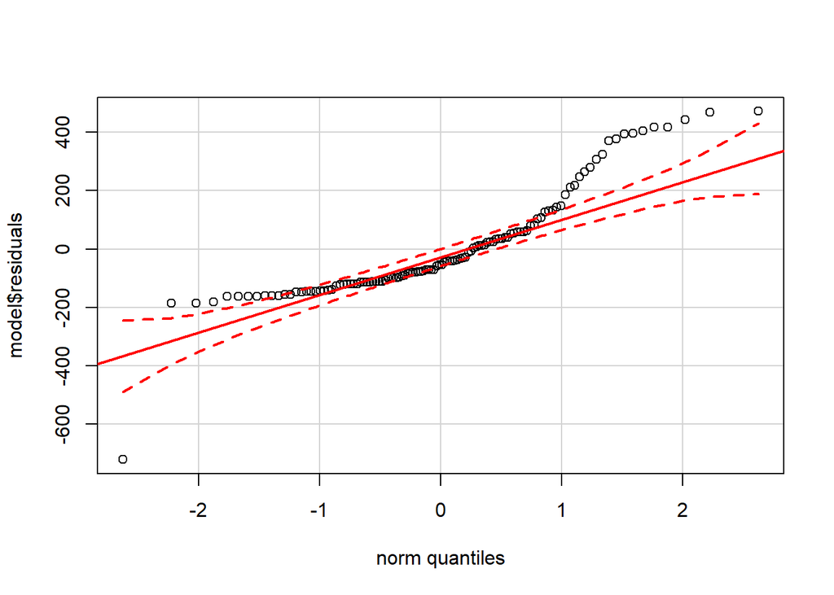

```r
qqPlot(model$residuals)
```

```r
s <- shapiro.test(model$residuals)
s #something went wrong with finding beta1
```

```
##
##  Shapiro-Wilk normality test
##
## data:  model$residuals
## W = 0.86291, p-value = 5.825e-09
```

# Data Transformations

What if the two conditions for a linear model aren’t met? Sometimes we can use the log transformation for positive numeric variables to get a better measure of centrality

- taking the log is a *power transformation*, along with a square root transformation and reciprocal transformation

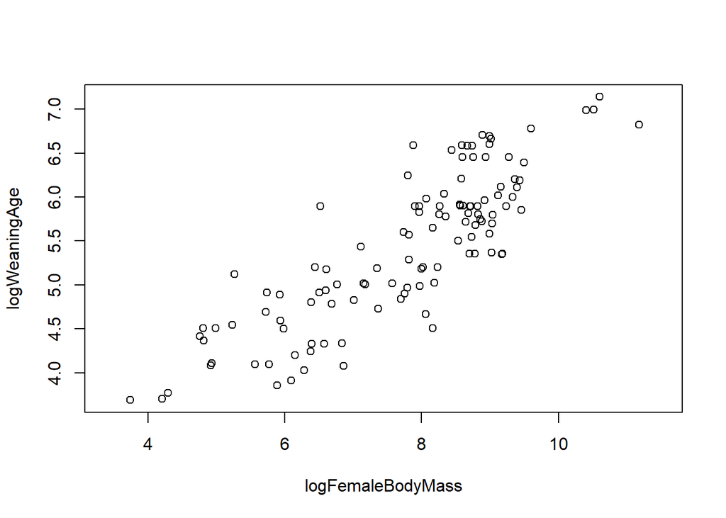

```r
d$logWeaningAge <- log(d$WeaningAge_d)
d$logFemaleBodyMass <- log(d$Body_mass_female_mean)
plot(data = d, logWeaningAge ~ logFemaleBodyMass)
```

```r
model <- lm(data = d, logWeaningAge ~ logFemaleBodyMass)
summary(model)
```

```
##
## Call:
## lm(formula = logWeaningAge ~ logFemaleBodyMass, data = d)
##
## Residuals:
##      Min       1Q   Median       3Q      Max
## -1.10639 -0.32736  0.00848  0.32214  1.11010
##
## Coefficients:
##                   Estimate Std. Error t value Pr(>|t|)
## (Intercept)         1.7590     0.2196   8.011 1.08e-12 ***
## logFemaleBodyMass   0.4721     0.0278  16.983  < 2e-16 ***
## ---
## Signif. codes:  0 '***' 0.001 '**' 0.01 '*' 0.05 '.' 0.1 ' ' 1
##
## Residual standard error: 0.4532 on 114 degrees of freedom
##   (97 observations deleted due to missingness)
## Multiple R-squared:  0.7167, Adjusted R-squared:  0.7142
## F-statistic: 288.4 on 1 and 114 DF,  p-value: < 2.2e-16
```

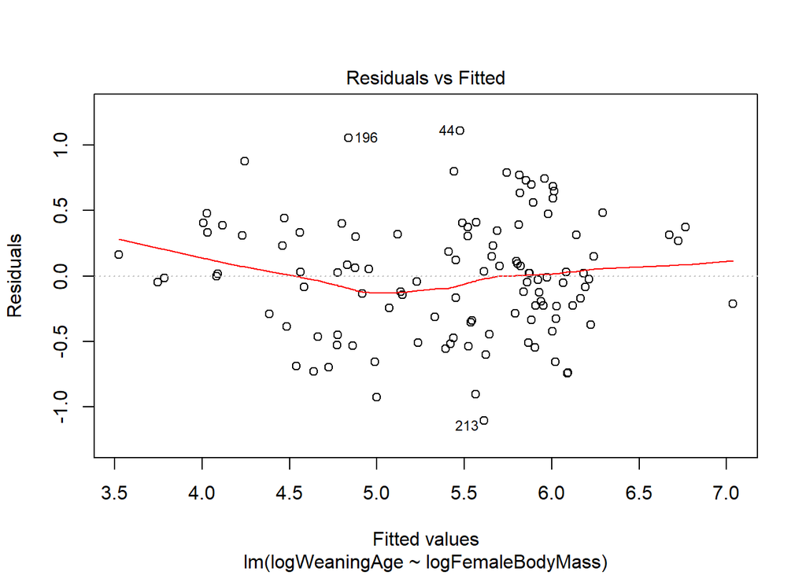

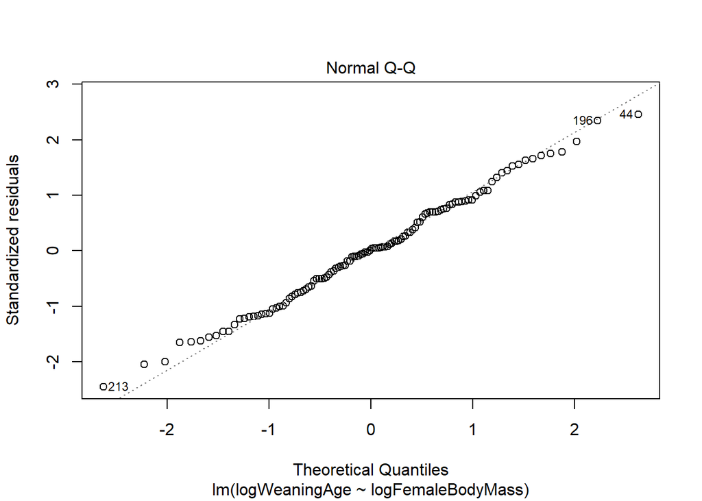

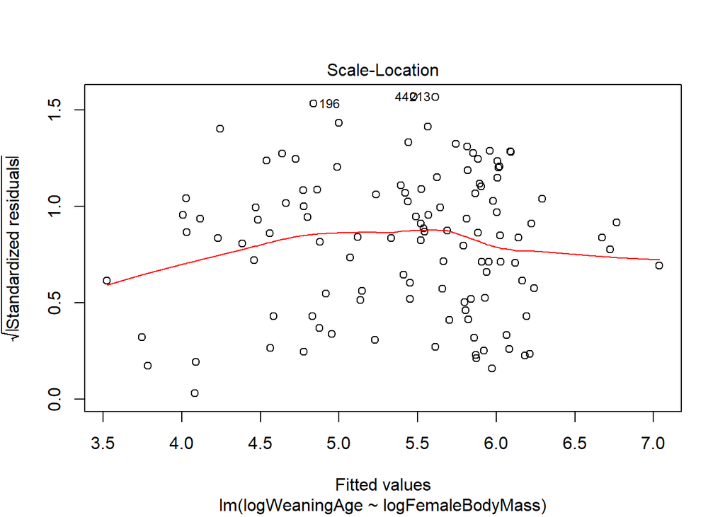

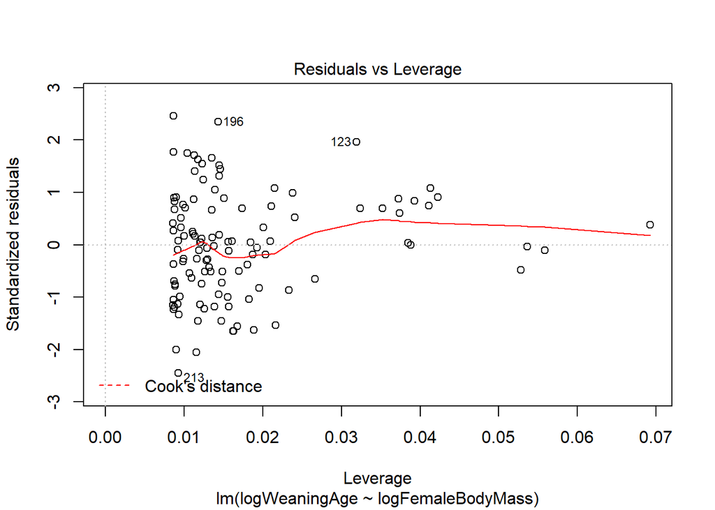

```r
plot(model)
```

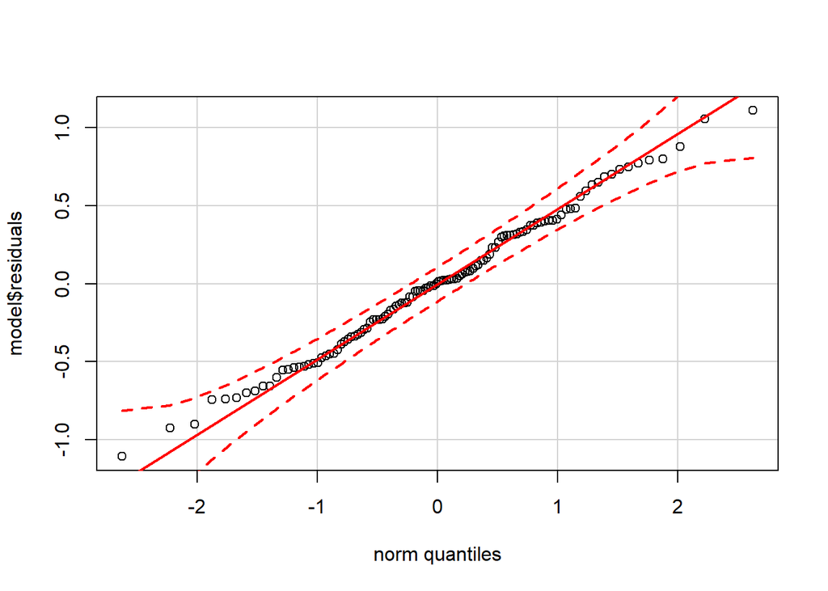

```r
qqPlot(model$residuals)
```

```r
s <- shapiro.test(model$residuals)
s
```

```
##
##  Shapiro-Wilk normality test
##
## data:  model$residuals
## W = 0.99367, p-value = 0.8793
```

Examples of useful transformations

1. logX: y = a + bln(x)
2. logY: y = exp(a + bx)
3. asymptotic: y = ax/ (1 + bx)
4. reciprocal: y = a + (b/x)
5. power law: y = ax^b
6. exponential: y = ae^(bx)

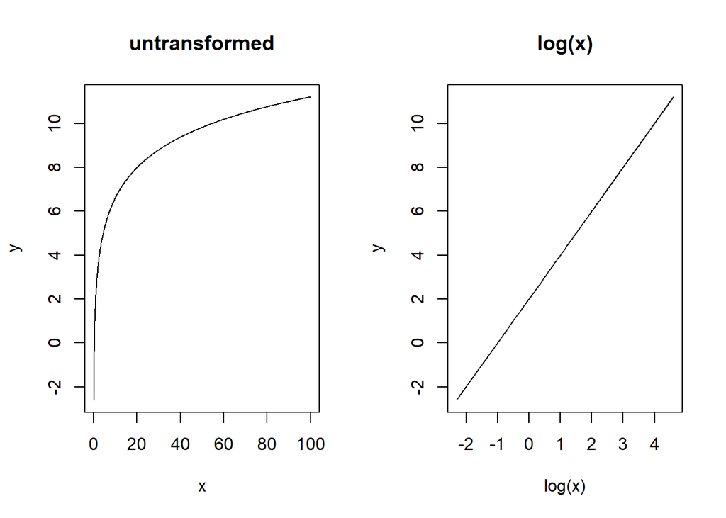

```r
par(mfrow = c(1, 2))

a <- 2
b <- 2

# log x
x <- seq(from = 0, to = 100, length.out = 1000)
y <- a + b * log(x)
plot(x, y, type = "l", main = "untransformed")
plot(log(x), y, type = "l", main = "log(x)")
```

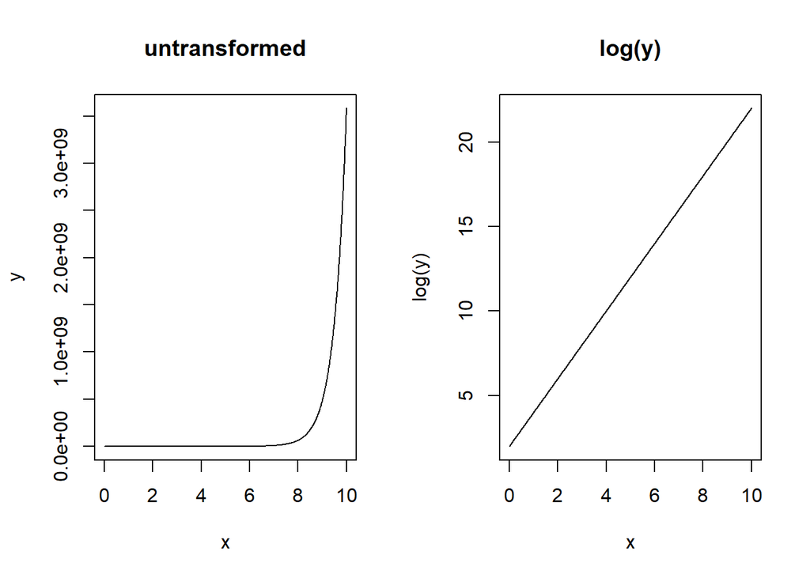

```r
# log y
x <- seq(from = 0, to = 10, length.out = 1000)
y <- exp(a + b * x)
plot(x, y, type = "l", main = "untransformed")
plot(x, log(y), type = "l", main = "log(y)")
```

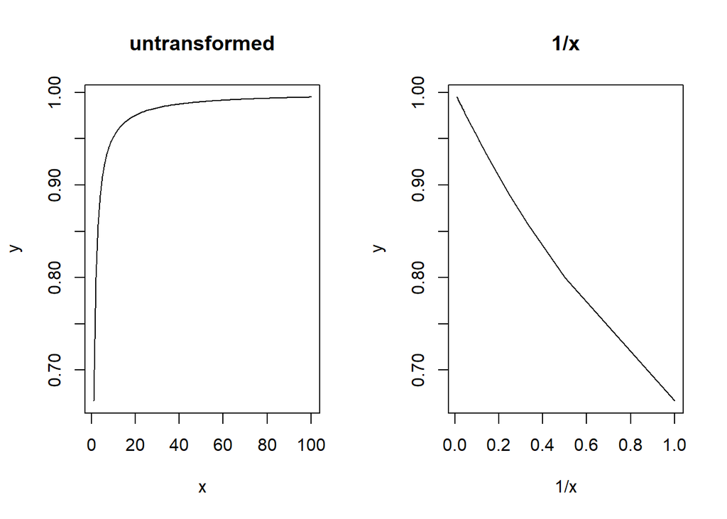

```r
# assymptotic
x <- seq(from = 1, to = 100, length.out = 100)
y <- (a * x)/(1 + b * x)
plot(x, y, type = "l", main = "untransformed")
plot(1/x, y, type = "l", main = "1/x")
```

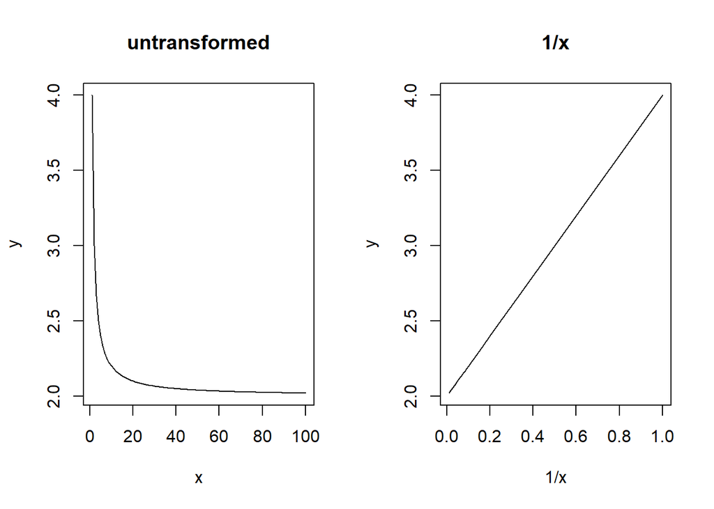

```r
# reciprocal
x <- seq(from = 1, to = 100, length.out = 100)
y <- a + b/x
plot(x, y, type = "l", main = "untransformed")
plot(1/x, y, type = "l", main = "1/x")
```

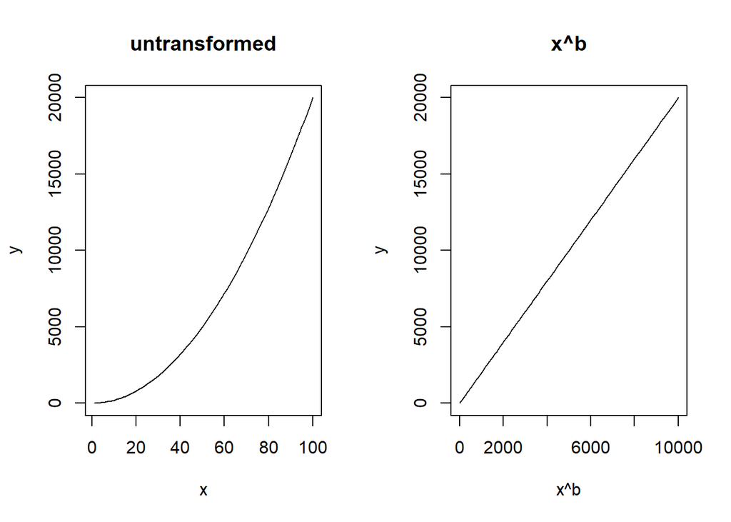

```r
# power
x <- seq(from = 1, to = 100, length.out = 100)
y <- a * x^b
plot(x, y, type = "l", main = "untransformed")
plot(x^b, y, type = "l", main = "x^b")
```

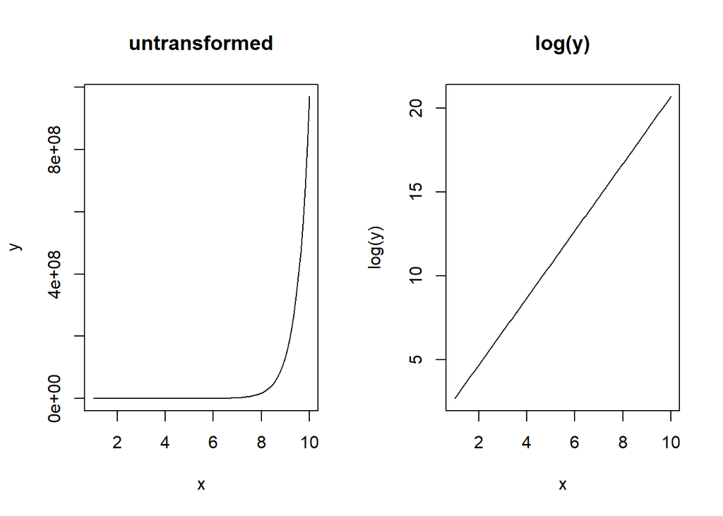

```r
# exp
x <- seq(from = 1, to = 10, length.out = 100)
y <- a * exp(b * x)
plot(x, y, type = "l", main = "untransformed")
plot(x, log(y), type = "l", main = "log(y)")
```

Sometimes you have to be careful when dealing with transformations, and should be able to go between the transformation and actual data to make sure everything is working the way it should.